# Assignment 5 - SVM

Ziwen Zhang

2023-07-21

## Dataset

Use the “Heart” dataset saved in the module that contains a binary outcome AHD for 303 patients who presented with chest pain. An outcome value of Yes indicates the presence of heart disease based on an angiographic test, while No means no heart disease. There are 13 predictors including Age, Sex, Chol (a cholesterol measurement), and other heart and lung function measurements.

```r
# load libraries
library(tidyverse)
library(caret)
library(e1071)
library(MASS)
library(pROC)
# load the data set
heart <- read.csv("heart.csv")[,-1]

# change the data types
heart$Thal <- as.factor(heart$Thal) %>% as.numeric()
heart$AHD <- ifelse(heart$AHD == "No", 0, 1)
heart$ChestPain <- as.factor(heart$ChestPain) %>% as.numeric()

# view datatype
str(heart)
```

```
## 'data.frame':    303 obs. of  14 variables:
##  $ Age      : int  63 67 67 37 41 56 62 57 63 53 ...
##  $ Sex      : int  1 1 1 1 0 1 0 0 1 1 ...
##  $ ChestPain: num  4 1 1 2 3 3 1 1 1 1 ...
##  $ RestBP   : int  145 160 120 130 130 120 140 120 130 140 ...
##  $ Chol     : int  233 286 229 250 204 236 268 354 254 203 ...
##  $ Fbs      : int  1 0 0 0 0 0 0 0 0 1 ...
##  $ RestECG  : int  2 2 2 0 2 0 2 0 2 2 ...
##  $ MaxHR    : int  150 108 129 187 172 178 160 163 147 155 ...
##  $ ExAng    : int  0 1 1 0 0 0 0 1 0 1 ...
##  $ Oldpeak  : num  2.3 1.5 2.6 3.5 1.4 0.8 3.6 0.6 1.4 3.1 ...
##  $ Slope    : int  3 2 2 3 1 1 3 1 2 3 ...
##  $ Ca       : int  0 3 2 0 0 0 2 0 1 0 ...
##  $ Thal     : num  1 2 3 2 2 2 2 2 3 3 ...
##  $ AHD      : num  0 1 1 0 0 0 1 0 1 1 ...
```

## Goal:

Recreate the four graphs from the SVM lecture notes (7.SVM_Annotated.pdf) page 29 and 30.

## Question 1 - Data Wrangling

Filter out missing values from the “heart” dataset and split the data in 207 patients in the training data and 90 patients in the test data. You can use seed=23453 to reproduce the results from the solution that will be posted for this Assignment.

```r
# filter out missing values
heart_clean <- na.omit(heart)

# split the data in 207 patients in training data and 90 in testing data
set.seed(24543)
train_idx <- createDataPartition(heart_clean$AHD, p = 0.694, list = FALSE)
training_data <- heart_clean[train_idx, ]
test_data <- heart_clean[-train_idx, ]

# check the dimensions of the data sets
nrow(training_data) # Should be 207
```

```
## [1] 207
```

```r
nrow(test_data)     # Should be 90
```

```
## [1] 90
```

## Question 2

Perform a linear SVM or a support vector classifier with cost = 0.01 and gamma of 2 on the training set. Also perform a linear discriminant analysis (LDA) on the same training data. Plot the ROC curve for the Support Vector Classifier and LDA in the same plot. Comment on the performance of the two methods on training data.

```r
# separate the predictors and outcome variable
x_train <- training_data[, 1:13] # eliminate the target
y_train <- training_data$AHD # set as the target

# perform svm with cost=0.01 and gamma=2
svm_model <- svm(AHD ~ ., data = training_data, kernel = "linear", cost = 0.01, gamma = 2)

# perform LDA on the same training data
lda_model <- lda(AHD ~ ., data = training_data)

# predict target values
svm_train_pred <- predict(svm_model, newdata = x_train, type = "Response")
lda_train_pred <- predict(lda_model, newdata = x_train, type = "Response")$posterior[,2]

# calculate ROC
svm_roc <- roc(y_train, svm_train_pred)
lda_roc <- roc(y_train, lda_train_pred)
# calculate AUC
svm_auc <- auc(svm_roc) %>% round(4)
lda_auc <- auc(lda_roc) %>% round(4)
paste("The AUC for SVM is: ", svm_auc)
```

```
## [1] "The AUC for SVM is:  0.9027"
```

```r
paste("The AUC for LDA is: ", lda_auc)
```

```
## [1] "The AUC for LDA is:  0.9144"
```

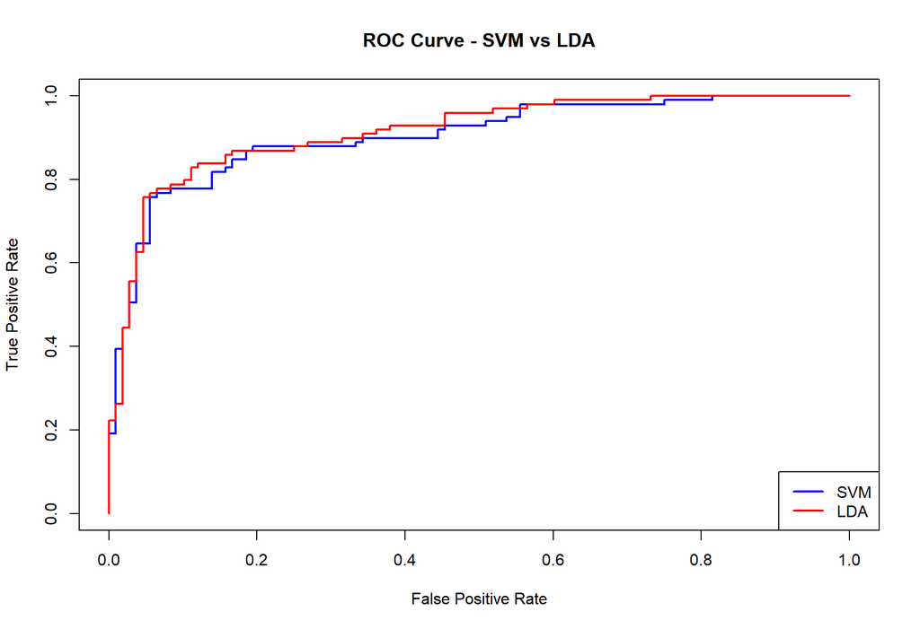

```r
# calculate True/False Positive rate
true_positive_svm <- svm_roc$sensitivities
true_positive_lda <- lda_roc$sensitivities
false_positive_svm <- 1-svm_roc$specificities
false_positive_lda <- 1-lda_roc$specificities

# plot ROC curves
plot(false_positive_svm, true_positive_svm, col = "blue", main = "ROC Curve - SVM vs LDA", xlab = "False Positive Rate", ylab = "True Positive Rate", type = "s", lwd = 2)
lines(false_positive_lda, true_positive_lda, col = "red", type = "s", lwd = 2)
legend("bottomright", legend = c("SVM", "LDA"), col = c("blue", "red"), lwd = 2)
```

**Comments:**

From the plot, we can see that the area under curve (AUC) for LDA is slightly larger than that for SVM, indicating that LDA performs better on the training dataset.

## Question 3

Perform a non-linear SVM with “radial” kernel on training data with three gamma values of 10^-1, 10^-2, 10^-3 and compare with the linear classifier of (1). You can use cross-validation to choose the cost parameter for each of these four methods. Plot the ROC curve for these four methods on the training data. Comment on the results.

### cross-validation for best cost parameter

```r
# linear SVM with cross-validation
svm_linear <- tune(svm, AHD ~ ., data = training_data, kernel = "linear", ranges = list(cost=c(0.001 , 0.01, 0.1, 1,5,10,100)) )

# non-linear SVM with cross-validation
svm_radial_1 <- tune(svm, AHD ~ ., data = training_data, kernel = "radial",ranges = list(cost=c(0.001 , 0.01, 0.1, 1,5,10,100), gamma = 10^(-1)) )

svm_radial_2 <- tune(svm, AHD ~ ., data = training_data, kernel = "radial",ranges = list(cost=c(0.001 , 0.01, 0.1, 1,5,10,100), gamma = 10^(-2)) )

svm_radial_3 <- tune(svm, AHD ~ ., data = training_data, kernel = "radial",ranges = list(cost=c(0.001 , 0.01, 0.1, 1,5,10,100), gamma = 10^(-3)) )

# extract the best cost parameter
best_cost_linear <- svm_linear$best.parameters$cost
best_cost_radial_1 <- svm_radial_1$best.parameters$cost
best_cost_radial_2 <- svm_radial_2$best.parameters$cost
best_cost_radial_3 <- svm_radial_3$best.parameters$cost
```

### model training with best cost parameter

```r
svm_linear_best <- svm(AHD ~ ., data = training_data, kernel = "linear", cost = best_cost_linear)
svm_radial_1_best <- svm(AHD ~ ., data = training_data, kernel = "radial", cost = best_cost_radial_1, gamma = 10^(-1))
svm_radial_2_best <- svm(AHD ~ ., data = training_data, kernel = "radial", cost = best_cost_radial_2, gamma = 10^(-2))
svm_radial_3_best <- svm(AHD ~ ., data = training_data, kernel = "radial", cost = best_cost_radial_3, gamma = 10^(-3))
```

### Plot ROC for four methods

```r
# predict target values
svm_linear_train_pred <- predict(svm_linear_best, x_train, probability = TRUE)
svm_radial_1_train_pred <- predict(svm_radial_1_best, x_train, probability = TRUE)
svm_radial_2_train_pred <- predict(svm_radial_2_best, x_train, probability = TRUE)
svm_radial_3_train_pred <- predict(svm_radial_3_best, x_train, probability = TRUE)

# calculate ROC
svm_linear_roc <- roc(y_train, svm_linear_train_pred)
svm_radial_1_roc <- roc(y_train, svm_radial_1_train_pred)
svm_radial_2_roc <- roc(y_train, svm_radial_2_train_pred)
svm_radial_3_roc <- roc(y_train, svm_radial_3_train_pred)
# calculate AUC
svm_linear_auc <- auc(svm_linear_roc) %>% round(4)
svm_radial_1_auc <- auc(svm_radial_1_roc) %>% round(4)
svm_radial_2_auc <- auc(svm_radial_2_roc) %>% round(4)
svm_radial_3_auc <- auc(svm_radial_3_roc) %>% round(4)
paste("The AUC for linear SVM is: ", svm_linear_auc)
```

```
## [1] "The AUC for linear SVM is:  0.9027"
```

```r
paste("The AUC for radial SVM 1 is: ", svm_radial_1_auc)
```

```
## [1] "The AUC for radial SVM 1 is:  0.9764"
```

```r
paste("The AUC for radial SVM 2 is: ", svm_radial_2_auc)
```

```
## [1] "The AUC for radial SVM 2 is:  0.9082"
```

```r
paste("The AUC for radial SVM 3 is: ", svm_radial_3_auc)
```

```
## [1] "The AUC for radial SVM 3 is:  0.9029"
```

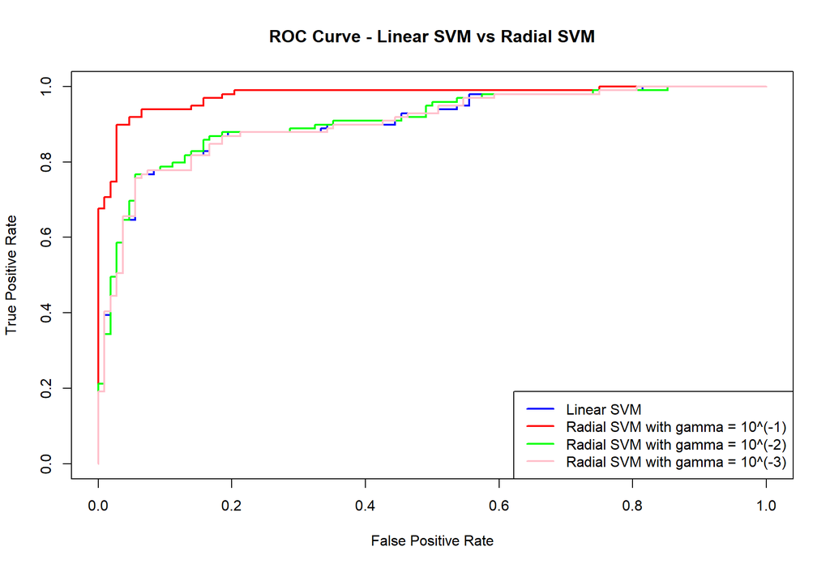

```r
# calculate True/False Positive rate
true_positive_svm_linear <- svm_linear_roc$sensitivities
true_positive_svm_radial_1 <- svm_radial_1_roc$sensitivities
true_positive_svm_radial_2 <- svm_radial_2_roc$sensitivities
true_positive_svm_radial_3 <- svm_radial_3_roc$sensitivities

false_positive_svm_linear <- 1-svm_linear_roc$specificities
false_positive_svm_radial_1 <- 1-svm_radial_1_roc$specificities
false_positive_svm_radial_2 <- 1-svm_radial_2_roc$specificities
false_positive_svm_radial_3 <- 1-svm_radial_3_roc$specificities

# plot ROC curves
plot(false_positive_svm_linear, true_positive_svm_linear, col = "blue", main = "ROC Curve - Linear SVM vs Radial SVM", xlab = "False Positive Rate", ylab = "True Positive Rate", type = "s", lwd = 2)
lines(false_positive_svm_radial_1, true_positive_svm_radial_1, col = "red", type = "s", lwd = 2)
lines(false_positive_svm_radial_2, true_positive_svm_radial_2, col = "green", type = "s", lwd = 2)
lines(false_positive_svm_radial_3, true_positive_svm_radial_3, col = "pink", type = "s", lwd = 2)
legend("bottomright", legend = c("Linear SVM", "Radial SVM with gamma = 10^(-1)", "Radial SVM with gamma = 10^(-2)", "Radial SVM with gamma = 10^(-3)"), col = c("blue", "red", "green", "pink"), lwd = 2)
```

**Comments:**

From the plot, we can see that the area under curve (AUC) for radial SVM with gamma = 10^(-1) is the largest, indicating that this model performs the best on the training dataset.

## Question 4

Compare the ROC curve of the five methods (3 non-linear SVM, 1 linear SVM and LDA) on the test data using the chosen values of the cost parameter. Comment on the results.

### generate predicted outcome on the testing dataset

```r
# separate the predictors and outcome variable
x_test <- test_data[, 1:13] # eliminate the target
y_test <- test_data$AHD # set as the target

# predict target values on testing data
svm_linear_test_pred <- predict(svm_linear_best, x_test, probability = TRUE)
svm_radial_1_test_pred <- predict(svm_radial_1_best, x_test, probability = TRUE)
svm_radial_2_test_pred <- predict(svm_radial_2_best, x_test, probability = TRUE)
svm_radial_3_test_pred <- predict(svm_radial_3_best, x_test, probability = TRUE)
lda_test_pred <- predict(lda_model, newdata = x_test, type = "Response")$posterior[,2]
```

### calculate ROC & AUC

```r
# calculate ROC
svm_linear_roc <- roc(y_test, svm_linear_test_pred)
svm_radial_1_roc <- roc(y_test, svm_radial_1_test_pred)
svm_radial_2_roc <- roc(y_test, svm_radial_2_test_pred)
svm_radial_3_roc <- roc(y_test, svm_radial_3_test_pred)
lda_roc <- roc(y_test, lda_test_pred)
# calculate AUC
svm_linear_auc <- auc(svm_linear_roc) %>% round(4)
svm_radial_1_auc <- auc(svm_radial_1_roc) %>% round(4)
svm_radial_2_auc <- auc(svm_radial_2_roc) %>% round(4)
svm_radial_3_auc <- auc(svm_radial_3_roc) %>% round(4)
lda_auc <- auc(lda_roc) %>% round(4)
paste("The AUC for linear SVM on test data is: ", svm_linear_auc)
```

```
## [1] "The AUC for linear SVM on test data is:  0.9124"
```

```r
paste("The AUC for radial SVM 1 on test data is: ", svm_radial_1_auc)
```

```
## [1] "The AUC for radial SVM 1 on test data is:  0.9271"
```

```r
paste("The AUC for radial SVM 2 on test data is: ", svm_radial_2_auc)
```

```
## [1] "The AUC for radial SVM 2 on test data is:  0.9145"
```

```r
paste("The AUC for radial SVM 3 on test data is: ", svm_radial_3_auc)
```

```
## [1] "The AUC for radial SVM 3 on test data is:  0.913"
```

```r
paste("The AUC for LDA on test data is: ", lda_auc)
```

```
## [1] "The AUC for LDA on test data is:  0.9119"
```

### calculate True/False Positive rate

```r
# calculate true positive rate
true_positive_svm_linear <- svm_linear_roc$sensitivities
true_positive_svm_radial_1 <- svm_radial_1_roc$sensitivities
true_positive_svm_radial_2 <- svm_radial_2_roc$sensitivities
true_positive_svm_radial_3 <- svm_radial_3_roc$sensitivities
true_positive_lda <- lda_roc$sensitivities

# calculate false positive rate
false_positive_svm_linear <- 1-svm_linear_roc$specificities
false_positive_svm_radial_1 <- 1-svm_radial_1_roc$specificities
false_positive_svm_radial_2 <- 1-svm_radial_2_roc$specificities
false_positive_svm_radial_3 <- 1-svm_radial_3_roc$specificities
false_positive_lda <- 1-lda_roc$specificities
```

### plot ROC curves

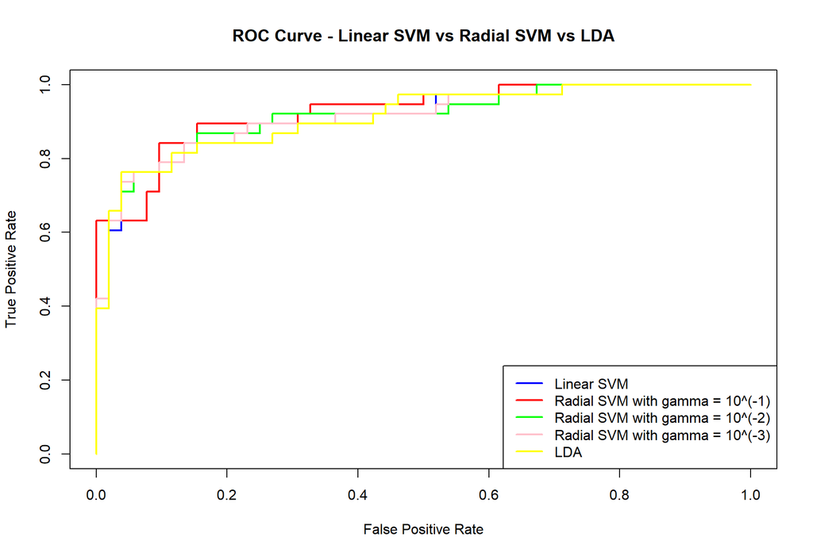

```r
plot(false_positive_svm_linear, true_positive_svm_linear, col = "blue", main = "ROC Curve - Linear SVM vs Radial SVM vs LDA", xlab = "False Positive Rate", ylab = "True Positive Rate", type = "s", lwd = 2)
lines(false_positive_svm_radial_1, true_positive_svm_radial_1, col = "red", type = "s", lwd = 2)
lines(false_positive_svm_radial_2, true_positive_svm_radial_2, col = "green", type = "s", lwd = 2)
lines(false_positive_svm_radial_3, true_positive_svm_radial_3, col = "pink", type = "s", lwd = 2)
lines(false_positive_lda, true_positive_lda, col = "yellow", type = "s", lwd = 2)
legend("bottomright", legend = c("Linear SVM", "Radial SVM with gamma = 10^(-1)", "Radial SVM with gamma = 10^(-2)", "Radial SVM with gamma = 10^(-3)", "LDA"), col = c("blue", "red", "green", "pink", "yellow"), lwd = 2)
```

**Comments:**

From the plot, we can see that the area under curve (AUC) for the five models seem similar, indicating that all of these models perform well on the testing dataset.